# Logistic regression

Load libraries

```r
library(tidyr)
library(dplyr)
```

```r
library(ggplot2)
```

1. Read the data from local folder and check for structure and dimensions

```r
data2020 <- read.table("C:/LocalData/kpuukko/IODS-project/data/alc.txt", sep="\t")

#There are 382 observations and 35 variables in the dataset
str(data2020)
```

```
## 'data.frame':    382 obs. of  35 variables:
##  $ school    : chr  "GP" "GP" "GP" "GP" ...
##  $ sex       : chr  "F" "F" "F" "F" ...
##  $ age       : int  18 17 15 15 16 16 16 17 15 15 ...
##  $ address   : chr  "U" "U" "U" "U" ...
##  $ famsize   : chr  "GT3" "GT3" "LE3" "GT3" ...
##  $ Pstatus   : chr  "A" "T" "T" "T" ...
##  $ Medu      : int  4 1 1 4 3 4 2 4 3 3 ...
##  $ Fedu      : int  4 1 1 2 3 3 2 4 2 4 ...
##  $ Mjob      : chr  "at_home" "at_home" "at_home" "health" ...
##  $ Fjob      : chr  "teacher" "other" "other" "services" ...
##  $ reason    : chr  "course" "course" "other" "home" ...
##  $ nursery   : chr  "yes" "no" "yes" "yes" ...
##  $ internet  : chr  "no" "yes" "yes" "yes" ...
##  $ guardian  : chr  "mother" "father" "mother" "mother" ...
```

[output cut: 21 more lines]

```r
dim(data2020)
```

```
## [1] 382  35
```

```r
colnames(data2020) #198 Female and 184 Male students
```

```
##  [1] "school"     "sex"        "age"        "address"    "famsize"
##  [6] "Pstatus"    "Medu"       "Fedu"       "Mjob"       "Fjob"
## [11] "reason"     "nursery"    "internet"   "guardian"   "traveltime"
## [16] "studytime"  "failures"   "schoolsup"  "famsup"     "paid"
## [21] "activities" "higher"     "romantic"   "famrel"     "freetime"
## [26] "goout"      "Dalc"       "Walc"       "health"     "absences"
## [31] "G1"         "G2"         "G3"         "alc_use"    "high_use"
```

```r
# Age distribution is from 15 to 22 years old, most of the students are 16 or 17 years old.
data2020 %>% group_by(age) %>% summarise(count = n())
```

```
## # A tibble: 7 x 2
##     age count
##   <int> <int>
## 1    15    81
## 2    16   107
## 3    17   100
## 4    18    81
## 5    19    11
## 6    20     1
## 7    22     1
```

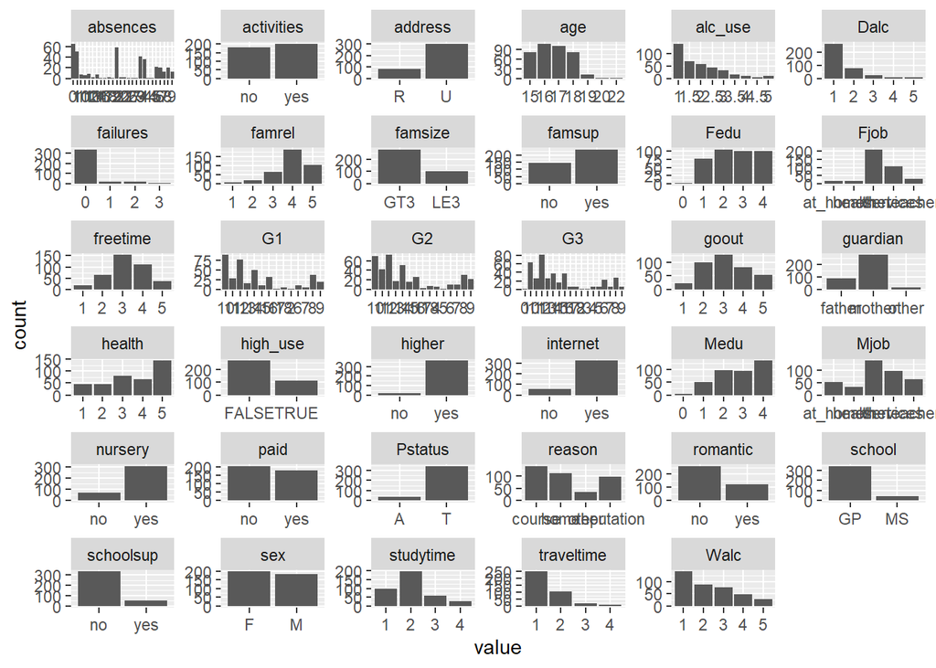

```r
#Draw a bar plot of each variable
gather(data2020) %>% ggplot(aes(value)) + facet_wrap("key", scales = "free") + geom_bar()
```

2. I will study the relationship between gender, school absenses, going out, famrel and alcohol consumption

Hypothesis

H1: Higher quality of family relationships reduce the risk for high alcohol consumption. H2: School absenses are positively related to high alcohol consumption. H3: Going out increases the risk for high alcohol consumption. H4: Men consume alcohol more than women.

3. Numerically and graphically explore the distributions of your chosen variables and their relationships with alcohol consumption (use for example cross-tabulations, bar plots and box plots). Comment on your findings and compare the results of your exploration to your previously stated hypotheses. (0-5 points)

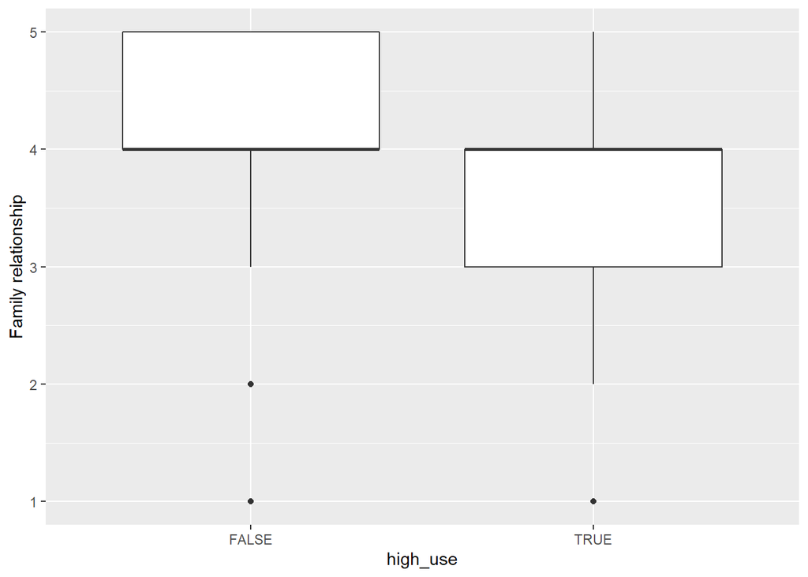

```r
# A box plot of high_use and family relationship
#As assumed, students who are high alcohol users have lower quality family relationships.
g1 <- ggplot(data2020, aes(x = high_use, y = famrel))
g1 + geom_boxplot() + ylab("Family relationship")
```